# Gene expression and cancer

Lovdip Singh

## Question of interest/goal of the study:

We are interested in seeing if there is an effect of the gene expression level of the gene ABCC5 on the risk of death due to cancer. We also want to know if the effect of the gene depends on the gender of the patient. We want to quantify these effects if they exist.

## Read in and inspect the data:

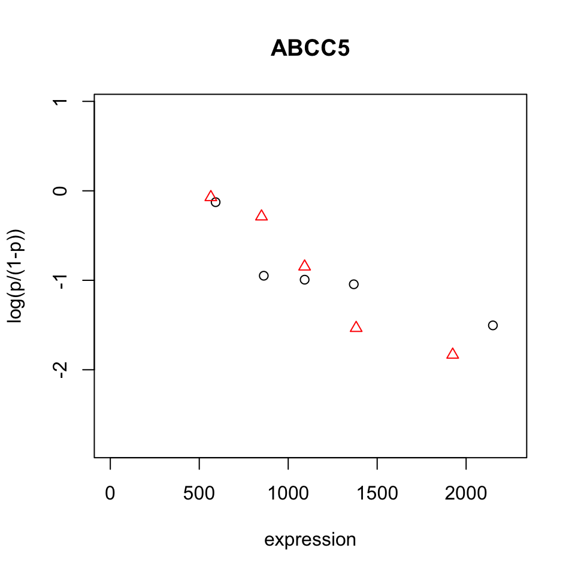

```r
gene.df=read.table("gene2.txt",header=TRUE)
gene.df$gender=as.factor(gene.df$gender)
# The following plot is logs( p/(1-p) ) of male (circle) and female (triangle) for groups of people with varying levels of gene  expression for the three different genes.
```

As the gene expression level increases, the Log-Odds appears to decrease, indicating the probability of death is lower for a greater level of gene expression for ABCC5. The trend for females appears to be steeper for females compared to males, showing that a similar increase in expression level appears to reduce the probability of death more for females than males.

## Model fitting

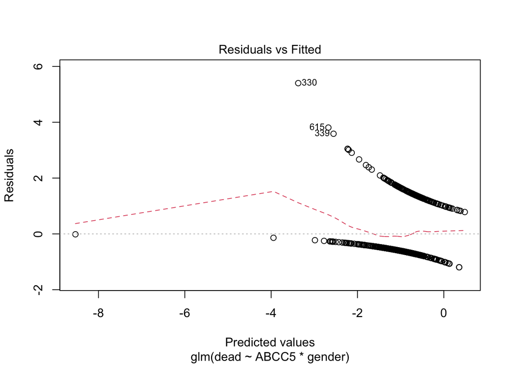

```r
#glm for 1 unit increase in gene expression
gene.fit <- glm(dead~ABCC5 * gender, family = binomial, data = gene.df)
plot(gene.fit, which = 1, lty = 2)
```

```r
summary(gene.fit)
```

```
##
## Call:
## glm(formula = dead ~ ABCC5 * gender, family = binomial, data = gene.df)
##
## Deviance Residuals:
##     Min       1Q   Median       3Q      Max
## -1.3318  -0.8659  -0.7438   1.3260   2.6103
##
## Coefficients:
##                    Estimate Std. Error z value Pr(>|z|)
## (Intercept)       0.8124944  0.3668794   2.215   0.0268 *
## ABCC5            -0.0015067  0.0003272  -4.604 4.14e-06 ***
## gendermale       -1.0832054  0.4667634  -2.321   0.0203 *
## ABCC5:gendermale  0.0009710  0.0004068   2.387   0.0170 *
## ---
## Signif. codes:  0 '***' 0.001 '**' 0.01 '*' 0.05 '.' 0.1 ' ' 1
##
## (Dispersion parameter for binomial family taken to be 1)
##
##     Null deviance: 817.95  on 673  degrees of freedom
## Residual deviance: 786.40  on 670  degrees of freedom
## AIC: 794.4
##
## Number of Fisher Scoring iterations: 4
```

```r
anova(gene.fit, test="Chisq")
```

```
## Analysis of Deviance Table
##
## Model: binomial, link: logit
##
## Response: dead
##
## Terms added sequentially (first to last)
##
##
##              Df Deviance Resid. Df Resid. Dev  Pr(>Chi)
## NULL                           673     817.95
## ABCC5         1  25.6550       672     792.29 4.082e-07 ***
## gender        1   0.0612       671     792.23   0.80462
## ABCC5:gender  1   5.8338       670     786.40   0.01572 *
## ---
## Signif. codes:  0 '***' 0.001 '**' 0.01 '*' 0.05 '.' 0.1 ' ' 1
```

```r
#glm for 100 unit increase in gene expression
gene.df$gender <- relevel(gene.df$gender, ref="female")
gene.df$ABCC5.100 <- gene.df$ABCC5 / 100
gene.fit2 <- glm(dead~ ABCC5.100 * gender, family = binomial, data = gene.df)
coefs <- coef(gene.fit2)
#exponentiate coeffecients for multiplicative effect
exp(coefs)
```

```
##          (Intercept)            ABCC5.100           gendermale
##            2.2535221            0.8601353            0.3385087
## ABCC5.100:gendermale
##            1.1019665
```

```r
exp(confint(gene.fit2))
```

```
##                          2.5 %    97.5 %
## (Intercept)          1.1099707 4.6954221
## ABCC5.100            0.8044640 0.9148785
## gendermale           0.1349411 0.8420755
## ABCC5.100:gendermale 1.0183340 1.1947208
```

```r
#reduction in odds as percentage
(100 * (1- exp(confint(gene.fit2))))[c(2,4),]
```

```
##                          2.5 %     97.5 %
## ABCC5.100            19.553600   8.512147
## ABCC5.100:gendermale -1.833397 -19.472078
```

```r
#difference with male baseline
gene.df$gender <- relevel(gene.df$gender, ref="male")
gene.fit3 <- glm(dead~ ABCC5.100 * gender, family = binomial, data = gene.df)
(100 * (1- exp(confint(gene.fit3))))[c(2,4),]
```

```
##                            2.5 %    97.5 %
## ABCC5.100               9.773228 0.9355074
## ABCC5.100:genderfemale 16.298434 1.8003891
```

## Method and Assumption Checks

The response variable for our data is the number of deaths due to cancer, and explanatory variables are gender (categorical) and ABCC5 expression level (numerical). As the response has a binary outcome and can be considered a binomial random variable, where a ‘success’ is considered death from cancer, we can model the data using a generalised linear model with a binomial response distribution. The plot of log-odds shows a negative trend with increasing gene expression level for the gene ABCC5. We fitted a logistic regression model to the data with an interaction term between gender and ABCC5 expression level, the interaction term was signification (P-value $\approx$ 0.016) and therefore was included in the final model and the model was not further simplified.

Our final model is:

$$log(Odds_i)=\beta_0+ \beta_1 \times ABCC5_i + \beta_2 \times genderMale_i + \beta_3 \times genderMale_i \times ABCC5_i$$

where $Odds_i$ is the odds of death from cancer, $ABCC5_i$ is the gene expression level for the gene ABCC5, and $genderMale_i$ is 1 if the patient is male or 0 otherwise.

## Executive Summary

We found that the expression level of the gene has an effect on the odds of death for females (P-value $\approx$ 0). Furthermore, we found that the interaction term between gene expression level and gender was significant in our model (P-value $\approx$ 0.016), this indicates that the effect of the gene expression level is different for males and females for odds of death.

We estimate that every 100 unit increase in ABCC5 gene expression level corresponds to a reduction in the odds of death for a cancer patient by between 19.6% and 8.5% for females.

For males, we estimate that every 100 unit increase in ABCC5 gene expression level corresponds to a reduction in the odds of death for a cancer patient by between 0.9%. to 9.8%.